# Projekt 1 - Strojenie hiperparametrów wybranych modeli

Witold Merkel, Michał Stawikowski, Adam Rydelek

15 - 04 - 2019

# 1 Wprowadzenie

Celem tego raportu jest przedstawienie procesu strojenia hiperparametrów wybranych trzech modeli, a następnie omówienie po krótce otrzymanych wyników oraz skomentowanie całego projektu. Sprawdzimy jak bardzo różnią się modele otrzymane poprzez strojenie od tych z domyślnymi ustawieniami. Dla przypomnienia w ostatniej fazie wybraliśmy następujące modele:

- `h2o.gbm`,
- `C50`,
- `h2o.randomForest`.

# 2 h2o.gbm

Optymalnych parametrów będziemy szukać na dwa spodoby: grid searchem oraz random searchem. Po przeczytaniu różnych artykułów zdecydowaliśmy, że najważniejsze oraz wprowadzające największe zmiany parametry tego modelu to:

- `ntrees` - parametr odpowiadający za ilość drzew,
- `max_depth` - odpowiada za maksymalną głębokość,
- `learn_rate` - jak model się uczy,
- `nbins` - na ile kubełków zostaną podzielone dane.

Przedstawimy jak sprawuje się model z domyślnymi parametrami.

```r
classif_lrn_t_h2ogbm_raw <- makeLearner("classif.h2o.gbm", predict.type = "prob")
model_h2ogbm_raw <- mlr::train(classif_lrn_t_h2ogbm_raw, classif_task_t)
predict_h2ogbm_raw <- predict(model_h2ogbm_raw, newdata = testOne, type='response')
perf_gbm_raw <- performance(predict_h2ogbm_raw, measures = list(acc, auc))
```

Jeżeli wyszkolimy model na tych parametrach to trzymujemy następujące własności.

```r
data.frame(AUC=0.7962832, ACC=0.7647628)
```

| AUC | ACC |
| --- | --- |
| 0.7962832 | 0.7647628 |

Szukane parametry są na takich przedziałach, że domyśla wartość do nich należy.

## 2.1 Grid search

Najpierw poszukamy najlepszych parametrów przy pomocy siatki i chodząc po punktach. Pokażemy też jakie wyniki otrzymuje najlepszy model otrzymany w ten sposób.

```r
rdesc <- makeResampleDesc("CV", iters = 3L)
ctrl_bst_grid <- makeTuneControlGrid(resolution = 5L)

ps_bst_gbm <- makeParamSet(
  makeNumericParam("ntrees", lower = 20, upper = 80),
  makeNumericParam("max_depth", lower = 1, upper = 10),
  makeNumericParam("learn_rate", lower = 0.05, upper = 0.14),
  makeNumericParam("nbins", lower = 15, upper = 24)
)

res_bst_gbm_grid <- tuneParams("classif.h2o.gbm", task = classif_task_t, resampling = rdesc,
                 par.set = ps_bst_gbm, control = ctrl_bst_grid, show.info = FALSE, measures = list(auc,acc))
```

Jeżeli wyszkolimy model na tych parametrach to trzymujemy następujące własności.

```r
data.frame(AUC=0.7859138, ACC=0.7481487)
```

| AUC | ACC |
| --- | --- |
| 0.7859138 | 0.7481487 |

## 2.2 Random search

Teraz poszukamy zestawu najlepzych parametrów przy pomocy randomowego skakania po punktach z określonej przestrzeni. Pokażemy też jakie wyniki otrzymuje najlepszy model otrzymany w ten sposób.

```r
ctrl_bst_random <- makeTuneControlRandom(maxit = 1000)

res_bst_gbm_random <- tuneParams("classif.h2o.gbm", task = classif_task_t, resampling = rdesc,
                 par.set = ps_bst_gbm, control = ctrl_bst_random, show.info = FALSE, measures = list(auc,acc))
```

Jeżeli wyszkolimy model na tych parametrach to trzymujemy następujące własności.

```r
data.frame(AUC=0.7862822, ACC=0.7575024)
```

| AUC | ACC |
| --- | --- |
| 0.7862822 | 0.7575024 |

## 2.3 Wnioski

Widać, że nie udało znaleźć się lepszego zestawu parametrów, ale zgodnie z oczekiwaniami te otrzymane przy randomowym szukaniu okazały się minimalnie lepsze. Możemy się jeszcze przyjrzeć wykresom wizualizującym wartość `AUC` w zależności od parametrów modelu i tego jak wpływa na to rodzaj szukania.

[figure not shown]

[figure not shown]

Powyżej przedstawione są zależności `AUC` od najważniejszych parametrów.

# 3 C50

Dla learnera C50 okazało się, że tuning parametrów:

- `CF` - tak zwany Confidence Factor,
- `trials` - liczba iteracji boostingu

ma sens, ponieważ ich zmiany z wartości domyślnej przynoszą spore zmiany. Dla parametrów takich, jak `subset`,`winnow`,`minCases` wartość domyślna okazała się optymalna.

Przedstawimy jak sprawuje się model z domyślnymi parametrami.

```r
classif_lrn_ctree <- makeLearner("classif.C50", predict.type = "prob")
model_ctree <- mlr::train(classif_lrn_ctree, classif_task_t)
predict_ctree <- predict(model_ctree, newdata = testOne, type='response')
perf_ctree <- performance(predict_ctree, measures = list(acc, auc))
perf_ctree
```

```
##       acc       auc
## 0.7478219 0.7503425
```

Teraz będziemy szukać lepszych parametrów optymalizując miary `Accuracy` i `AUC`.

## 3.1 Rozkład wartości parametrów

Aby lepiej zrozumieć w jakim przedziale powinniśmy zmieniać wartości parametrów i dla jakich wartości wyniki powinny być najlepsze wykonaliśmy kilka testów zmieniając różne wartości i w ten sposób powstały następujące wykresy, wykonane za pomocą funkcji *plotHyperParsEffect* z pakietu `mlr`.

### 3.1.1 Trials

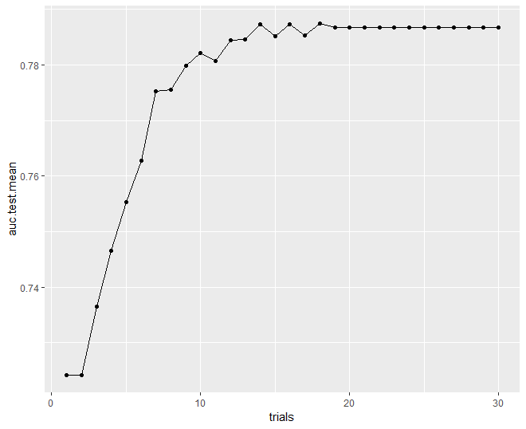

Można zauważyć, że liczba iteracji boostingu rośnie od 0 do około 20, a potem jest ciągle taka sama, więc najsensowniej będzie sprawdzać wartości w okolicach **15-25** iteracji.

### 3.1.2 CF

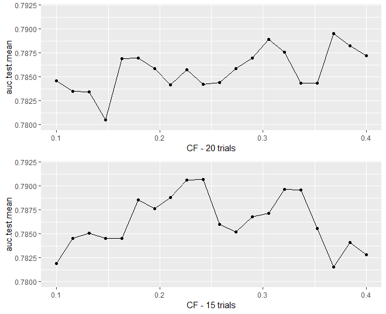

Przy poszukiwaniu optymalnych wartości *CF* można zauważyć, że dla różnej ilości *trials* wykresy się róznią, ale zazwyczaj to właśnie w przedziale **0.2-0.35** zawiera się optymalna wartość.

## 3.2 Grid search

```r
ctrl_ctree_grid <- makeTuneControlGrid(resolution = 1000L)

ps_ctree <- makeParamSet(
  makeIntegerParam("trials", lower = 0, upper = 40),
  makeNumericParam("CF", lower=0.01,upper=0.5)
)

ctree_grid <- tuneParams(classif_lrn_ctree, task = classif_task_t, resampling = rdesc,
                               par.set = ps_ctree, control = ctrl_ctree_grid, show.info = TRUE, measures = list(auc,acc))
```

Po przeszukaniu siatki wartości parametrów optymalne okazały się: *trials* = 23, *CF* = 0.119 i otrzymaliśmy następujące wyniki:

```r
data.frame(AUC=0.7865891, ACC=0.7461306)
```

| AUC | ACC |
| --- | --- |
| 0.7865891 | 0.7461306 |

## 3.3 Random search

```r
ps_ctree <- makeParamSet(
  makeIntegerParam("trials", lower = 15, upper = 25),
  makeNumericParam("CF", lower=0.2,upper=0.35)
)

ctrl_bst_random <- makeTuneControlRandom(maxit = 200)

ctree_random <- tuneParams(classif_lrn_ctree, task = classif_task_t, resampling = rdesc,
                         par.set = ps_ctree, control = ctrl_bst_random, show.info = TRUE, measures = list(auc,acc))
```

Uzyskanymi parametrami okazały się *trials* = 19 i *CF* = 0.212, które dały wynik:

```r
data.frame(AUC=0.7884702, ACC=0.7493283)
```

| AUC | ACC |
| --- | --- |
| 0.7884702 | 0.7493283 |

Można zauważyć, że wyniki również są o wiele wyższe od domyślnych i delikatnie lepsze od Grid Search.

## 3.4 Wnioski

Biorąc pod uwagę powyższe uwagi uznaliśmy, że liczba *trials* równa 23 daje ogółem optymalne wyniki, oraz, że *CF* równe 0.25 jest najlepsze i w ten sposób otrzymaliśmy parametry z zadowalającymi wynikami:

```r
data.frame(AUC=0.7918562, ACC=0.7437764)
```

| AUC | ACC |
| --- | --- |
| 0.7918562 | 0.7437764 |

# 4 h2o.randomForest

Kolejnym algorytmem jest też tak jak `C50` drzewiasta implementacja lasów losowych - `RandomForest`. Hiperparametry, które wybraliśmy do strojenia to:

- `ntrees` - czyli liczba użytych drzew decyzyjnych, parametr ten ma bardzo duży wpływ na czas obliczeń
- `max_depth` - który odpowiada za maksymalną głębokość drzew,
- `nbins` - odpowiadający za dzielenie danych na grupy.

Algorytm już z domyślnymi parametrami osiągał bardzo dobre wyniki:

```r
classif_task_t <- makeClassifTask(id = "task", data = trainOne, target = "is_recid")
classif_lrn_t_h2orf <- makeLearner("classif.h2o.randomForest", predict.type = "prob")
model_h2orf <- mlr::train(classif_lrn_t_h2orf, classif_task_t)
predict_h2orf <- predict(model_h2orf, newdata = testOne, type='response')
perf_rf_raw <- performance(predict_h2orf, measures = list(acc, auc))
```

```r
perf_rf_raw
```

```
##       acc       auc
## 0.7647628 0.7755033
```

Jak widać wyjściowe `ACC` i `AUC` jest i tak już dość wysokie, jednak zobaczymy czy uda nam się je choć trochę poprawić.

## 4.1 GridSearch

Na początku spróbowaliśmy wyszukać jak najlepszych parametrów w okolicach wartości domyślnych siatką poszukiwań.

```r
ps_rf <- makeParamSet(
  makeNumericParam("nbins", lower = 10, upper = 50),
  makeNumericParam("ntrees", lower = 10, upper = 50),
  makeNumericParam("max_depth", lower = 10, upper = 50)

)

ctrl_rf = makeTuneControlGrid(resolution = 5L)
res_rf <- tuneParams("classif.h2o.randomForest", task = classif_task_t, resampling = rdesc,
                      par.set = ps_rf, control = ctrl_rf,measures = list(auc,acc))
```

Najlepszymi znalezionymi parametrami okazały się: `nbins` = 40, `ntrees` = 40, `max_depth` = 10.

```r
classif_lrn_t_h2orf <- makeLearner("classif.h2o.randomForest", predict.type = "prob", nbins =40, ntrees=40, max_depth=10)
model_h2orf <- mlr::train(classif_lrn_t_h2orf, classif_task_t)
predict_h2orf <- predict(model_h2orf, newdata = testOne, type='response')
perf_rf_raw2 <- performance(predict_h2orf, measures = list(acc, auc))
```

```r
perf_rf_raw2
```

```
##       acc       auc
## 0.7613746 0.7749369
```

## 4.2 Model Based Optimization

### 4.2.1 Szybkie spojrzenie

Spróbujmy zobaczyć jak model będzie się zachowywał przy zmianie wcześniej wymienionych parametrów. Za pierwszym razem wykonamy tylko 5 iteracji, w celu zorientowania się.

```r
par.set = makeParamSet(
  makeNumericParam("nbins", 10, 100, trafo = function(x) ceiling(x)),
  makeNumericParam("ntrees", 10, 100, trafo = function(x)  ceiling(x)),
  makeNumericParam("max_depth", 10, 20,trafo = function(x) ceiling(x))
)

ctrl2 = makeMBOControl()
ctrl2 = setMBOControlTermination(ctrl2, iters = 5)
tune.ctrl = makeTuneControlMBO(mbo.control = ctrl2)
resMBO = tuneParams(makeLearner("classif.h2o.randomForest",predict.type = "prob"), classif_task_t, cv3, par.set = par.set, control = tune.ctrl,
                    show.info = FALSE, measures = list(auc, acc))
```

```r
resMBO
```

```
## Tune result:
## Op. pars: nbins=64; ntrees=66; max_depth=17
## auc.test.mean=0.7899042
```

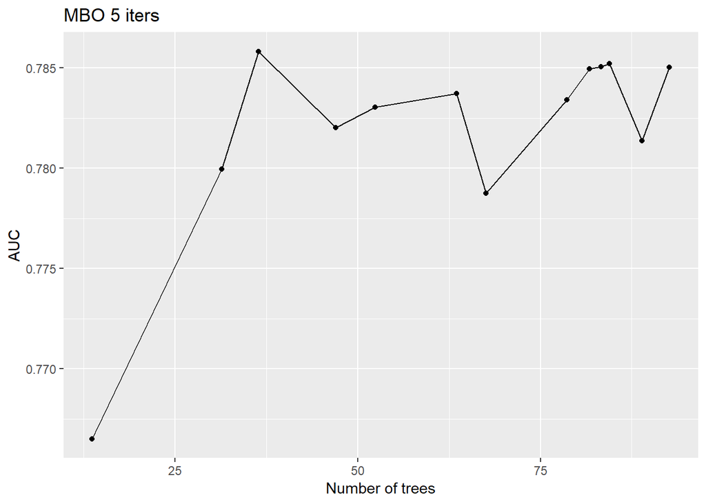

```r
data1 = generateHyperParsEffectData(resMBOBT)
plot1 <- plotHyperParsEffect(data1, x = "ntrees", y = "auc.test.mean",
                             plot.type = "line") + xlab("Number of trees") + ylab("AUC") + ggtitle("MBO 5 iters")
plot1
```

Liczba drzew.

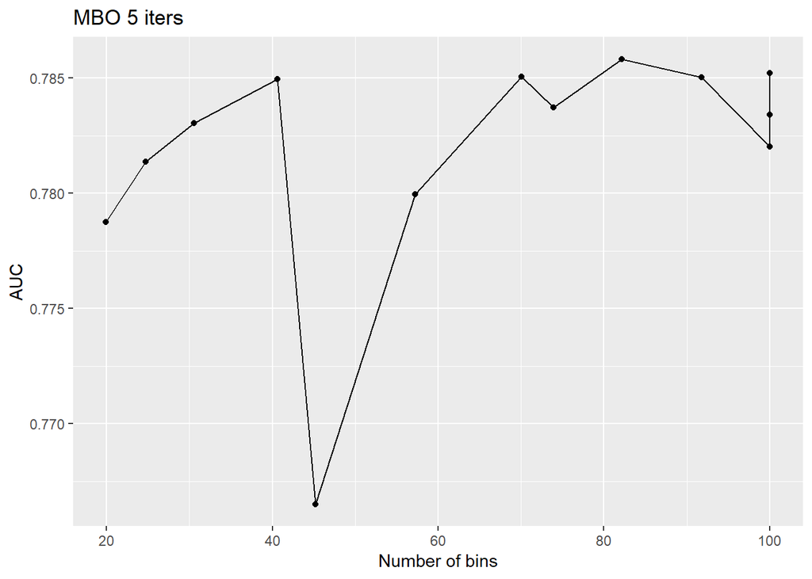

```r
plot2 <- plotHyperParsEffect(data1, x = "nbins", y = "auc.test.mean",
                             plot.type = "line") + xlab("Number of bins") + ylab("AUC") + ggtitle("MBO 5 iters")
plot2
```

Liczba kubełków.

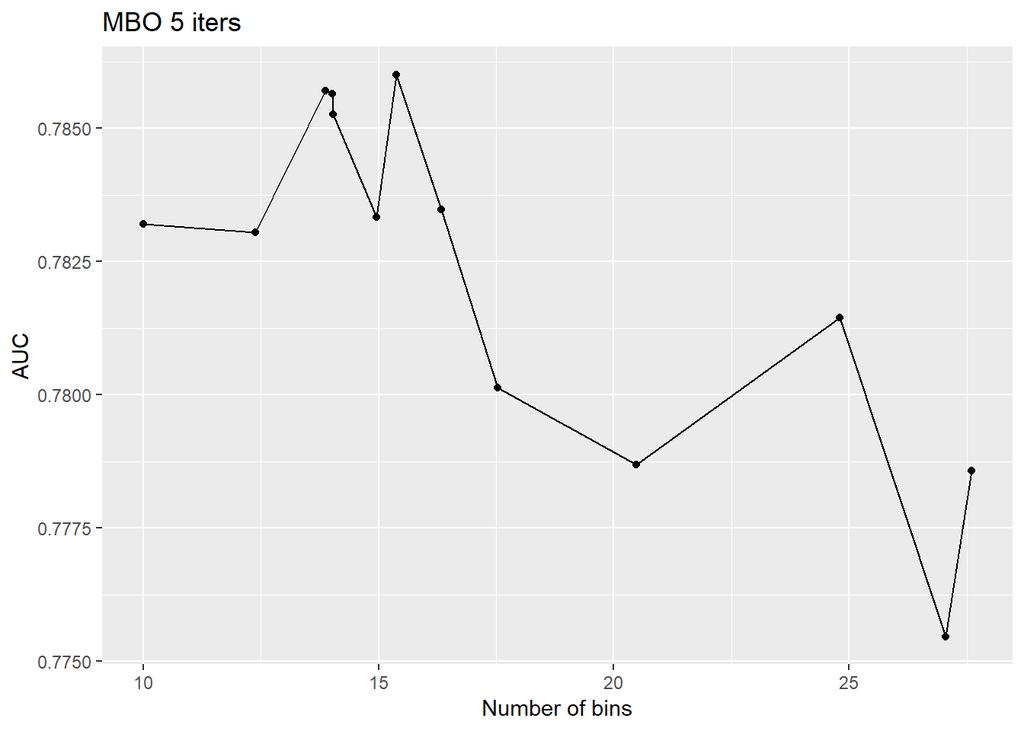

```r
data2 = generateHyperParsEffectData(resMBOBTD)

plot3 <- plotHyperParsEffect(data2, x = "max_depth", y = "auc.test.mean",
                             plot.type = "line") + xlab("Number of bins") + ylab("AUC") + ggtitle("MBO 5 iters")
plot3
```

Maksymalna głębokość.

Wnisokując z powyższych wykresów spróbujemy poszukać lepszych parametrów.

```r
par.setB = makeParamSet(
  makeNumericParam("nbins", 100, 250, trafo = function(x) ceiling(x)),
  makeNumericParam("ntrees", 100, 250, trafo = function(x)  ceiling(x)),
  makeNumericParam("max_depth", 10, 20,trafo = function(x) ceiling(x))
)

ctrl2B = makeMBOControl()
ctrl2B = setMBOControlTermination(ctrl2B, iters = 20)
tune.ctrlB = makeTuneControlMBO(mbo.control = ctrl2B)
resMBOB = tuneParams(makeLearner("classif.h2o.randomForest",predict.type = "prob"), classif_task_t, cv3, par.set = par.setB, control = tune.ctrlB,
                    show.info = FALSE, measures = list(auc, acc))
```

Tym razem wykonamy 20 iteracji i zwiększymy zakres `nbins` oraz `ntrees`.

```r
resMBOB
```

```
## Tune result:
## Op. pars: nbins=242; ntrees=232; max_depth=17
## auc.test.mean=0.7918085
```

Uzyskaliśmy jeszcze lepszy wynik i prawdopodobnie zwiększając liczbę drzew i kubełków otrzymalibyśmy znowu ciut lepsze wyniki.

# 5 Podsumowanie

Każdy model po strojeniu hiperparametrów bardzo zbliżył się do progu `0.8 AUC`, przekroczenie go to prawdopodobnie kwestia większej ilości iteracji w celu poszukiwania jeszcze lepszych parametrów. Jest to zadawalający wyniki biorąc pod uwagę początkowe `~0.7 AUC`. Dzięki `inżynierii cech`, `wyborowi modeli` oraz `strojeniu hiperparametrów` udało nam się podnieść początkowe AUC o `0.1`.